# Scientific Question: How structurally similar are the active domain of murine coagulation FVIII and human coagulation FVIII in terms of its interaction with VWF?

Coagulation Factor VIII: Factor VIII (FVIII) is an essential blood-clotting protein, also known as anti-hemophilic factor (AHF). In humans, factor VIII is encoded by the F8 gene. Defects in this gene result in hemophilia A, a recessive X-linked coagulation disorder. FVIII circulates in bloodstream in inactive form, bound to the von Willebrand factor(VWF), until an injury occurs.

von Willebrand factor: VWF is a blood glycoprotein involved in hemostasis, specifically, platelet adhesion, which bind to FVIII in the bloodstream for stablization.

Data source: The human, mouse, angola, rabbit FVIII amino acid sequences are obtained from the NCBI websites (ID: AAA52420.1; ID: EDL29229.1; NP_001164742.1; XP_011818598.1)

Human FVIII structure is obtained from the swiss protein websites (https://swissmodel.expasy.org/templates/6mf2.1)

Human FVIII interaction with VWF structure is also obtained from the PDB database with ID: 7KWO

# Hypothesis: If murine coagulation FVIII is sequentially and structurally similar to human FVIII, then mouse model missing FVIII would have symptoms that are similar to human hemophila A patients.

Method for analysis:

Multiple sequence alignment is used to get the alignment of the FVIII AA sequences of four species for further sequence logo visualization.

Sequence Logo: From the aligned AA sequences, the key AA portion is extracted as the input for Sequence Logo analysis. (Note: the key sequence here refers to the residues arounr Y1680 in human FVIII, since this residue is identified as key for FVIII to interact with VWF in Fuller et al. study) From the sequence logo, the similarity or difference between human and mouse amino acid seuqence around the key Y1680 are more visible. Also, the sequence logo of 4 sequence allows the determination of significant difference (for example, if for an residue position, mouse is the only one that is different from human, it can be a significant difference)

Fuller, James R, et al. “Molecular Determinants of the Factor VIII/Von Willebrand Factor Complex Revealed by BIVV001 Cryo-Electron Microscopy.” Blood, 2021, doi:10.1182/blood.2020009197.

Homology modeling: There is no mouse FVIII 3D structure available on the PDB database. Therefore, SWISS Protein websites is used to conduct the homology modeling for generation of mouse FVIII structure. Human FVIII (6mf2.1) is used as the template (https://swissmodel.expasy.org/interactive/6TgHKQ/models/)

PDB: PDB read-in is used to show the 3D structure of human FVIII, mouse FVIII, and Human FVIII & VWF in the notebook.

PyMol software: PyMol is used to superimpose (Align) the Mouse FVIII and Human FVIII 3D structure. Moreover, PyMol is used to select the key AA(Y1680) in FVIII and key AA(R816) in VWF that are important for FVIII and VWF interactions. Those selected residues generates a separate PDB formated file and is shown below.

3D protein analysis: Multiple 3D protein analysis are conducted to analyze the difference and similarity between human and mouse FVIII structure and key atom differences. The composition of secondary structure of human and mouse FVIII are obtained for comparing the structural similarity. The distances between alpha carbon of Y1680 in human and mouse separately and the R816 in VWF are calculated to see if the key interaction between VWF and FVIII are different in human and mouse.

# Loading in Packages

Definition of Packages:

logomaker: Logomaker is a Python package for generating sequence logos, which can generate both standard and highly customized logos to illustrate the properties of DNA, RNA, or protein sequences.

Bio: BioPython package is commonly used for bioinformatics analysis. It is a collection of modules which provides many different functions to deal with various genetic structures such as DNA, RNA and protein sequence operations.

PDB: PDB is a module in BioPython that is used to process and visualize 3D structures of macromolecules like proteins.

SeqIO: SeqIO is a module in BioPython which can be used to read and write files containing sequence information in multiple formats.

MafftCommandline: MAFFT is a multiple sequence alignment program which offers a range of multiple alignment methods.

AlignIO: AlignIO is a module in BioPython which can be used to read or write sequence alignment data files in multiple formats.

Nglview: NglView package is an IPython widget which allows the interactive visualization of the 3D structures of molecules.

Bio.SeqUtils.ProtParam: Bio.SeqUtils.ProtParam is a module of Bio.SeqUtils which is a aollection of modeules that provides different functions to analyze the sequence property of proteins.

IPython: IPython.display is a module of IPython that is a public API for display tools.

```python
pip install logomaker
```

```python
import Bio
from Bio import SeqIO
from Bio import PDB
from Bio.Align.Applications import MafftCommandline
from Bio import AlignIO
from Bio.SeqUtils.ProtParam import ProteinAnalysis
from Bio.PDB import *
from IPython.display import display, Image
import logomaker as lm
import nglview as nv
```

# Bioinformatic Analysis

```python
# Multiple Sequence Alignment
# MAFFT multiple sequence alignment is used below. The input for MAFFT alignment is a FASTA formated file
# that contains all the fasta seuqence for alignment. By finding the best alignment of the sequences, MAFFT
# would write the alignment to stdout, which need to be saved to a file and then parse by AlignIO
# Read in Fasta files of coagulation factor VIII from 4 species
Mouse_seq = SeqIO.read('Mouse_seq.fasta', 'fasta')
Human_seq = SeqIO.read('Human_seq.fasta', 'fasta')
Rabbit_seq = SeqIO.read('Rabbit_seq.fasta', 'fasta')
Angola_seq = SeqIO.read('Angola_seq.fasta', 'fasta')
# Check the read-in of sequences
print(Mouse_seq)
print(Human_seq)
print(Rabbit_seq)
print(Angola_seq)

# Mafft Multiple Sequence Alignment
# Provide the path of the pre-installed mafft application
mafft_exe = "/usr/local/bin/"
# Provide the input path of the read-in fasta file
in_file = "Four_seq.fasta"
# Alignment
mafft_cline = MafftCommandline(input=in_file)
print(mafft_cline)
# Get the stoudt file
stdout, stderr = mafft_cline()
# Write stoudt file into fasta file that can be parsed
with open("aligned.fasta", "w") as handle:
    handle.write(stdout)
# Parse the aligned sequence containing file into align
align = AlignIO.read("aligned.fasta", "fasta")

# Global variable Multi_seq, which is an empty list by now. Since this variable would be
# called and used globally, I define it as the global variable.
Multi_seq = list()
# Function to extract sequence from multiple sequence alignment into a list of sequence
# Input parameter is alignment and a list
def Seq_extract(alignment, Multi_seq):
    for align in alignment:
        # Obtain the sequence from alignment, the portion contains the key Y1680 in between
        seq = align.seq[2120:2160]
        # Convert the sequence into string object
        # Both seq and seq_str are local variables, since I only need to call them within the function
        seq_str = str(seq)
        # Append the string of seq onto the list
        Multi_seq.append(seq_str)
    return Multi_seq
# Global variable since I want to keep this list as input for sequence logo
Seq_list = list()
# Extract the important portions of sequences from alignment, Seq_list will be returned with needed information
Seq_extract(align, Seq_list)
# Check the extraction
print(Seq_list)
```

```
ID: EDL29229.1
Name: EDL29229.1
Description: EDL29229.1 coagulation factor VIII [Mus musculus]
Number of features: 0
Seq('MQIALFACFFLSLFNFCSSAIRRYYLGAVELSWNYIQSDLLSVLHTDSRFLPRM...QQY')
ID: AAA52420.1
Name: AAA52420.1
Description: AAA52420.1 coagulation factor VIII [Homo sapiens]
Number of features: 0
Seq('MQIELSTCFFLCLLRFCFSATRRYYLGAVELSWDYMQSDLGELPVDARFPPRVP...DLY')
ID: NP_001164742.1
Name: NP_001164742.1
Description: NP_001164742.1 coagulation factor VIII [Oryctolagus cuniculus]
Number of features: 0
Seq('MQIELSTCFFVCILQLSFSATRRYYLGAVELSWDYMHSDLLSELHVDTRSPPRM...QLY')
ID: XP_011818598.1
Name: XP_011818598.1
Description: XP_011818598.1 PREDICTED: coagulation factor VIII [Colobus angolensis palliatus]
Number of features: 0
Seq('MQIELSTCFFLCLLRFCFSATRRYYLGAVELSWDYMQSDLGELPVDTRFPPRVP...ELY')
mafft Four_seq.fasta
['RQKFSSLYISQFIIMYSLDGKKWQTYRGNSTGTLMVFFGN', 'RQKFSSLYISQFIIMYSLDGKKWQTYRGNSTGTLMVFFGN', 'RQKFSSLYISQFIIMYSLDGKKWQTYRGNSTGTLMVFFGN', 'RQKFSSLYISQFIIMYSLDGKKWLSYQGNSTGTLMVFFGN']
```

```python
# PDB reading
# PDB read-in is used to show the 3D structure of human FVIII, mouse FVIII, and Human FVIII & VWF
# Human PDB 6mf2.1
Human_FVIII_Parser = PDBParser()
# Get the structure of Human FVIII from the PDB file Human_FVIII.pdb
Human_structure = Human_FVIII_Parser.get_structure("Human_FVIII", "Human_FVIII.pdb")
# Show structures
nv.show_biopython(Human_structure)
```

```python
# Mouse PDB Homology modeling
# Homology Modeling is conducted to get the 3D structure of Mouse FVIII based on the Human FVIII template
Mouse_FVIII_Parser = PDBParser()
# Get the structure of Mouse FVIII from the PDB file Mouse_FVIII.pdb
Mouse_structure = Mouse_FVIII_Parser.get_structure("Mouse_FVIII", "Mouse_FVIII.pdb")
nv.show_biopython(Mouse_structure)
# There is no Mouse FVIII available on the PDB website and I used homology modeling in Swiss Protein to use
# 6mf2.1 as the template to model the structure of mouse FVIII. The Seq Identity is 82.58% GMQE is 0.34
```

```python
#Human FVIII interaction with VWF
VWF_FVIII_Parser = PDBParser()
# Get the structure of Human FVIII and VWF from the PDB file VWF_FVIII.pdb
VWF_FVIII_structure = VWF_FVIII_Parser.get_structure("VWF_FVIII", "VWF_FVIII.pdb")
nv.show_biopython(VWF_FVIII_structure)
# Discontinuous is because this PDB file contasin two separate protein(VWF and FVIII)
```

```python
# Human FVIII Y1295 and Mouse FVIII Y2102 interaction with VWF R816
Distance_Parser = PDBParser()
# Get the structure of Human FVIII Y1295 and Mouse FVIII Y2102 interaction with VWF R816
# from the PDB file Distance.pdb
Distance_structure = Distance_Parser.get_structure("Distance", "Distance.pdb")
# Show the structure
nv.show_biopython(Distance_structure)
```

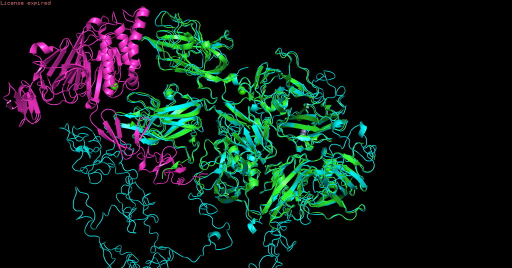

```python
# Display the superimposed Human FVIII(green) and Mouse FVIII(blue) along with VWF (purple)
display(Image(filename='Superimpose.png'))
```